# **Predicting Drug Sensitivity in Cancer (GDSC)**

## **Overview:**

> In this project, you will explore a real-world dataset on drug sensitivity in cancer, focusing on how genomic features influence response to treatment. Please note that the goal is not to arrive at a single correct answer, but to investigate patterns in the data, ask meaningful and contextual biological questions, demonstrate various data handling and cleaning techniques and of course, communicate results clearly.

> Try as much as possible to be innovative, creative and use clear graphics to showcase your results clearly.

## **Metadata**

> Columns: Description

> COSMIC_ID: Unique Identifier on COSMIC

> CELL_LINE_NAME: Name of cell line

> TCGA_DESC: TCGA Code for cancer type

> DRUG_ID: Drug ID

> DRUG_NAME: Drug Name

> LN_IC50: Natural logarithm of the IC50

> AUC: Area under the dose dependent curve

> Z_SCORE: Z score of deviations from the mean of zero; the closer to zero, the better

> GDSC Tissue descriptor 1: System description

> GDSC Tissue descriptor 2: Specific organ or tissue

> Cancer Type (matching TCGA label): Same as the TCGA

> Microsatellite instability Status (MSI): MSI-L (Minor instability), MSI-H; High instability, MSS: No instability or repaired mutation

> Screen Medium: Medium for screening

> Growth Properties: Growth properties

> CNA: Is copy number altered?

> Gene Expression: Is gene expressed?

> Methylation: Is gene methylated?

> TARGET: genetic target of drug

> TARGET_PATHWAY: pathway of genetic target

## **Understanding the dataset**

```
Shape of the dataset: (162103, 19)
```

### **Comments**

> The dataset contains 162103 rows and 19 columns (variables) with each column representing the each of the variable.

```
First 5 rows of the dataset:
```

|  | COSMIC_ID | CELL_LINE_NAME | TCGA_DESC | DRUG_ID | DRUG_NAME | LN_IC50 | AUC | Z_SCORE | GDSC Tissue descriptor 1 | GDSC Tissue descriptor 2 | Cancer Type (matching TCGA label) | Microsatellite instability Status (MSI) | Screen Medium | Growth Properties | CNA | Gene Expression | Methylation | TARGET | TARGET_PATHWAY |
| --- | --- | --- | --- | --- | --- | --- | --- | --- | --- | --- | --- | --- | --- | --- | --- | --- | --- | --- | --- |
| 0 | 683667 | PFSK-1 | MB | 1003 | Camptothecin | -1.463887 | 0.930220 | 0.433123 | nervous_system | medulloblastoma | MB | MSS/MSI-L | R | Adherent | Y | Y | Y | TOP1 | DNA replication |
| 1 | 687448 | COLO-829 | SKCM | 1003 | Camptothecin | -1.235034 | 0.867348 | 0.557727 | skin | melanoma | SKCM | MSS/MSI-L | R | Adherent | Y | Y | Y | TOP1 | DNA replication |
| 2 | 687455 | RT4 | BLCA | 1003 | Camptothecin | -2.963191 | 0.821438 | -0.383200 | urogenital_system | Bladder | BLCA | MSS/MSI-L | D/F12 | Adherent | Y | Y | Y | TOP1 | DNA replication |
| 3 | 687457 | SW780 | BLCA | 1003 | Camptothecin | -1.449138 | 0.905050 | 0.441154 | urogenital_system | Bladder | BLCA | MSS/MSI-L | D/F12 | Adherent | Y | Y | Y | TOP1 | DNA replication |
| 4 | 687459 | TCCSUP | BLCA | 1003 | Camptothecin | -2.350633 | 0.843430 | -0.049682 | urogenital_system | Bladder | BLCA | MSS/MSI-L | D/F12 | Adherent | Y | Y | Y | TOP1 | DNA replication |

```
Last 5 rows of the dataset:
```

|  | COSMIC_ID | CELL_LINE_NAME | TCGA_DESC | DRUG_ID | DRUG_NAME | LN_IC50 | AUC | Z_SCORE | GDSC Tissue descriptor 1 | GDSC Tissue descriptor 2 | Cancer Type (matching TCGA label) | Microsatellite instability Status (MSI) | Screen Medium | Growth Properties | CNA | Gene Expression | Methylation | TARGET | TARGET_PATHWAY |
| --- | --- | --- | --- | --- | --- | --- | --- | --- | --- | --- | --- | --- | --- | --- | --- | --- | --- | --- | --- |
| 162098 | 1659818 | MM1S | MM | 2499 | N-acetyl cysteine | 9.316959 | 0.988236 | -0.775041 | myeloma | myeloma | MM | MSS/MSI-L | R | Suspension | Y | Y | Y | Metabolism | Metabolism |
| 162099 | 1659928 | SNU-175 | COREAD | 2499 | N-acetyl cysteine | 10.127082 | 0.976746 | 0.156872 | large_intestine | large_intestine | COAD/READ | MSI-H | R | Suspension | Y | Y | Y | Metabolism | Metabolism |
| 162100 | 1660034 | SNU-407 | COREAD | 2499 | N-acetyl cysteine | 8.576377 | 0.913378 | -1.626959 | large_intestine | large_intestine | COAD/READ | MSI-H | R | Adherent | Y | Y | Y | Metabolism | Metabolism |
| 162101 | 1660035 | SNU-61 | COREAD | 2499 | N-acetyl cysteine | 10.519636 | 0.975001 | 0.608442 | large_intestine | large_intestine | COAD/READ | MSS/MSI-L | R | Adherent | Y | Y | Y | Metabolism | Metabolism |
| 162102 | 1674021 | SNU-C5 | COREAD | 2499 | N-acetyl cysteine | 10.694579 | 0.969969 | 0.809684 | large_intestine | large_intestine | COAD/READ | MSI-H | R | Adherent | Y | Y | Y | Metabolism | Metabolism |

### **Key Variables in the Dataset**

```
Information about the dataset:
<class 'pandas.core.frame.DataFrame'>
RangeIndex: 162103 entries, 0 to 162102
Data columns (total 19 columns):
 #   Column                                   Non-Null Count   Dtype
---  ------                                   --------------   -----
 0   COSMIC_ID                                162103 non-null  int64
 1   CELL_LINE_NAME                           162103 non-null  object
 2   TCGA_DESC                                162103 non-null  object
 3   DRUG_ID                                  162103 non-null  int64
 4   DRUG_NAME                                162103 non-null  object
 5   LN_IC50                                  162103 non-null  float64
 6   AUC                                      162103 non-null  float64
 7   Z_SCORE                                  162103 non-null  float64
 8   GDSC Tissue descriptor 1                 162103 non-null  object
 9   GDSC Tissue descriptor 2                 162103 non-null  object
 10  Cancer Type (matching TCGA label)        162103 non-null  object
 11  Microsatellite instability Status (MSI)  162103 non-null  object
 12  Screen Medium                            162103 non-null  object
 13  Growth Properties                        162103 non-null  object
 14  CNA                                      162103 non-null  object
 15  Gene Expression                          162103 non-null  object
 16  Methylation                              162103 non-null  object
 17  TARGET                                   162103 non-null  object
 18  TARGET_PATHWAY                           162103 non-null  object
dtypes: float64(3), int64(2), object(14)
memory usage: 23.5+ MB
```

#### **Comments**

> All columns have 162103 non-null entries, which indicates that there are no missing values across any of the 19 columns (or variables).

> Therefore, there is no immediate need for cleaning related to missing data.

## **Building a Machine Learning Model to Predict Drug Sensitivity (with LN_IC50 as the prediction target.)**

```
Features selected: ['COSMIC_ID', 'DRUG_ID', 'CNA_num', 'Gene_Expression_num', 'Methylation_num']
Target variable: LN_IC50
Shape of X: (162103, 5)
Shape of y: (162103,)
```

### **Task Formulation: Regression Task**

> This problem is framed as a regression task. The objective is to predict the LN_IC50 (Natural logarithm of the IC50), which is a continuous numerical value representing drug sensitivity.

> This is clearly indicated by the problem description, the selection of the LN_IC50 column as the target variable, and the use of regression models like RandomForestRegressor and XGBRegressor, along with regression-specific evaluation metrics such as R-squared, MAE, and RMSE throughout the analysis.

### **Splitting the Data into Training, Validation, and Testing Sets**

The dataset was split into 80% training data, 10% validation data, and 10% testing data to allow tuning of the hyperparameters on the validation set and evaluation of the final model's performance on unseen test data.

```
X_train shape: (129682, 5)
y_train shape: (129682,)
X_val shape: (16210, 5)
y_val shape: (16210,)
X_test shape: (16211, 5)
y_test shape: (16211,)
```

### **Leakage Prevention**

> **Strict Data Splitting:** The most crucial step in preventing data leakage was splitting the dataset into distinct training, validation, and testing sets (80/10/10 split) at the very beginning of the modeling process, before any model training or hyperparameter tuning.

> Training Set (X_train, y_train): Used exclusively for training the models.

> Validation Set (X_val, y_val): Used for hyperparameter tuning (e.g., in RandomizedSearchCV and Optuna's objective function) to select the best model configuration without biasing the final evaluation.

> **Cross-Validation:** K-fold cross-validation was employed for the best-performing model (Optuna-tuned XGBoost) to provide a more robust estimate of its performance and assess its generalization capability across different subsets of the data, further guarding against a single, potentially lucky, train-test split.

> By following these rigorous steps, the task ensured that the models were evaluated fairly on data they had not seen during training or tuning, providing a reliable measure of their true predictive power and avoiding optimistic performance estimates due to data leakage.

### **Training a RandomForestRegressor Model**

> A RandomForestRegressor, a powerful ensemble learning method, known for its good performance and ability to handle various types of data was train on the training data.

```
Training the RandomForestRegressor model...
Model training complete.
```

### **Evaluating the Model**

We will evaluate the model's performance on the test set using common regression metrics: R-squared, Mean Absolute Error (MAE), and Root Mean Squared Error (RMSE).

```
R-squared (R2) score: 0.6649
Mean Absolute Error (MAE): 1.2318
Root Mean Squared Error (RMSE): 1.6455
```

### **Visualize Predicted vs. Actual LN_IC50 Values**

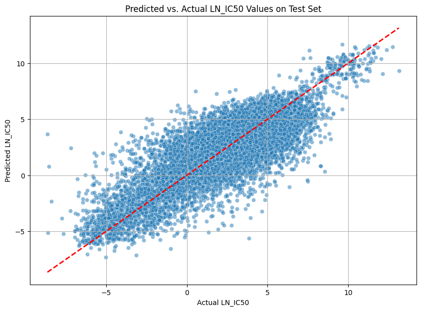

#### **Comments**

> This scatter plot visualizes the performance of the trained RandomForestRegressor model by comparing the Predicted LN_IC50 values against the Actual LN_IC50 values on the test set. Each point represents a data instance, with its actual drug sensitivity on the x-axis and the model's prediction on the y-axis. The red dashed line represents a perfect prediction, where the predicted value is exactly equal to the actual value.

From this plot, you can observe:

> **Clustering around the red line:** Ideally, for a well-performing model, all the data points should cluster tightly around the red dashed line. The closer the points are to this line, the more accurate the model's predictions are.

> **Spread of the points:** The scatter of the points around the red line indicates the model's error. A wider spread suggests more significant discrepancies between actual and predicted values. In this plot, there's a noticeable spread, especially at higher and lower LN_IC50 values, indicating that while the model captures the general trend, there's room for improvement in its predictive accuracy.

## **Hyperparameter Tuning to Improve Model Performance**

> Hyperparameter tuning was performed to improve the model's performance, especially the R-squared score. This involves searching for the best combination of parameters for our `RandomForestRegressor`.

### **Defining the Parameter Distribution and Search Strategy**

> Using `RandomizedSearchCV` from `sklearn` to efficiently search a defined distribution of hyperparameters. This approach is generally faster than `GridSearchCV` for large search spaces, while still providing good results.

Here are some common hyperparameters for `RandomForestRegressor` that will be tuned:

- `n_estimators`: The number of trees in the forest.
- `max_features`: The number of features to consider when looking for the best split.
- `min_samples_split`: The minimum number of samples required to split an internal node.
- `min_samples_leaf`: The minimum number of samples required to be at a leaf node.
- `bootstrap`: Whether bootstrap samples are used when building trees.

```
RandomizedSearchCV initialized.
```

### **Training the Tuned Model**

> Fitting `RandomizedSearchCV` to the training data. This process will involve building multiple models with different hyperparameter combinations and evaluating them using cross-validation to find the best performing set of parameters.

```
Starting hyperparameter search...
Fitting 3 folds for each of 20 candidates, totalling 60 fits
Hyperparameter search complete.
Best parameters found: {'bootstrap': True, 'max_features': None, 'min_samples_leaf': 4, 'min_samples_split': 7, 'n_estimators': 89}
Best estimator (tuned model) has been trained.
```

#### **Comments**

> The results of the hyperparameter tuning process using RandomizedSearchCV for the RandomForestRegressor model.

> **Fitting 3 folds for each of 20 candidates, totalling 60 fits:** This line tells us that RandomizedSearchCV explored 20 different combinations of hyperparameters (called 'candidates'). For each of these 20 combinations, it performed 3-fold cross-validation. This means the model was trained and evaluated 3 times per candidate, resulting in a total of 60 model training and evaluation runs.

> **Best parameters found:** {'bootstrap': True, 'max_features': None, 'min_samples_leaf': 4, 'min_samples_split': 7, 'n_estimators': 89}:

> This is the most crucial part of the output. After evaluating all 20 hyperparameter combinations through cross-validation, RandomizedSearchCV identified this specific set of parameters as the best, meaning they resulted in the highest average performance (based on the default scoring metric, which is R-squared for regression models). These parameters define the structure and behavior of the optimal RandomForestRegressor found during this search:

> bootstrap: True means that bootstrap samples were used when building trees.

> max_features: None indicates that all features were considered when looking for the best split.

> min_samples_leaf: 4 means that each leaf node in a tree must have at least 4 samples.

> min_samples_split: 7 means that a node must have at least 7 samples to be considered for splitting.

> n_estimators: 89 means the ensemble contains 89 decision trees.

> Best estimator (tuned model) has been trained: This confirms that a RandomForestRegressor model has been trained using the identified best_params and is now ready for further evaluation on the test set.

### **Evaluating the Tuned Model**

> Evaluating the tuned model on the test set and compare its performance (especially R-squared) with the original model after finding the best hyperparameters.

```
Tuned Model R-squared (R2) score: 0.7196
Tuned Model Mean Absolute Error (MAE): 1.1332
Tuned Model Root Mean Squared Error (RMSE): 1.5053

--- Performance Comparison ---
Original Model R2: 0.6649
Tuned Model R2: 0.7196
Original Model MAE: 1.2318
Tuned Model MAE: 1.1332
Original Model RMSE: 1.6455
Tuned Model RMSE: 1.5053
```

## **Feature Engineering: Including Categorical Variables**

> To further improve the model, feature engineering was performed by including categorical variables, starting with `TARGET_PATHWAY`. One-hot encoding was used to convert this categorical feature into a numerical format suitable for the machine learning model.

```
DataFrame shape after one-hot encoding TARGET_PATHWAY: (162103, 44)
```

|  | COSMIC_ID | CELL_LINE_NAME | TCGA_DESC | DRUG_ID | DRUG_NAME | LN_IC50 | AUC | Z_SCORE | GDSC Tissue descriptor 1 | GDSC Tissue descriptor 2 | ... | TP_JNK and p38 signaling | TP_Metabolism | TP_Mitosis | TP_Other | TP_Other, kinases | TP_PI3K/MTOR signaling | TP_Protein stability and degradation | TP_RTK signaling | TP_WNT signaling | TP_p53 pathway |
| --- | --- | --- | --- | --- | --- | --- | --- | --- | --- | --- | --- | --- | --- | --- | --- | --- | --- | --- | --- | --- | --- |
| 0 | 683667 | PFSK-1 | MB | 1003 | Camptothecin | -1.463887 | 0.930220 | 0.433123 | nervous_system | medulloblastoma | ... | False | False | False | False | False | False | False | False | False | False |
| 1 | 687448 | COLO-829 | SKCM | 1003 | Camptothecin | -1.235034 | 0.867348 | 0.557727 | skin | melanoma | ... | False | False | False | False | False | False | False | False | False | False |
| 2 | 687455 | RT4 | BLCA | 1003 | Camptothecin | -2.963191 | 0.821438 | -0.383200 | urogenital_system | Bladder | ... | False | False | False | False | False | False | False | False | False | False |
| 3 | 687457 | SW780 | BLCA | 1003 | Camptothecin | -1.449138 | 0.905050 | 0.441154 | urogenital_system | Bladder | ... | False | False | False | False | False | False | False | False | False | False |
| 4 | 687459 | TCCSUP | BLCA | 1003 | Camptothecin | -2.350633 | 0.843430 | -0.049682 | urogenital_system | Bladder | ... | False | False | False | False | False | False | False | False | False | False |

5 rows × 44 columns

### **Updating Features and Retraining the Model**

> Updating the feature set to include the newly created one-hot encoded `TARGET_PATHWAY` columns. Then, re-splitting the data, train the `RandomForestRegressor` with the best parameters found during tuning, and evaluating its performance.

```
New features selected: ['COSMIC_ID', 'DRUG_ID', 'CNA_num', 'Gene_Expression_num', 'Methylation_num', 'TP_ABL signaling', 'TP_Apoptosis regulation', 'TP_Cell cycle', 'TP_Chromatin histone acetylation', 'TP_Chromatin histone methylation', 'TP_Chromatin other', 'TP_Cytoskeleton', 'TP_DNA replication', …
Shape of new X: (162103, 28)
Shape of new y: (162103,)

New X_train shape: (129682, 28)
New X_val shape: (16210, 28)
New X_test shape: (16211, 28)
New y_train shape: (129682,)
New y_val shape: (16210,)
New y_test shape: (16211,)
```

### **Feature Selection**

> AUC (Area Under the Curve) and Z_SCORE are highly leakage-prone variables and were correctly excluded from the feature set when building the predictive model for LN_IC50. Their removal is justified because:

> **Direct Measures of Drug Sensitivity:** LN_IC50, AUC, and Z_SCORE are all different metrics used to quantify drug sensitivity or response, often derived from the same experimental dose-response curves. Including AUC or Z_SCORE as features when trying to predict LN_IC50 would be akin to providing the answer directly to the model.

> **Information Not Available at Prediction Time:** In a real-world application, if you are predicting LN_IC50 for a new drug-cell line combination, you would not have its AUC or Z_SCORE values until after the experiment is conducted (at which point you would also have the LN_IC50). Using these as features would imply that such information is available beforehand, leading to an overly optimistic and unrealistic model performance.

> **Strong Correlation:** These metrics are typically highly correlated. Their inclusion would allow the model to learn a spurious correlation or a simple transformation between them, rather than learning meaningful relationships from truly independent biological and chemical features. This would result in a model that performs well on training data but fails to generalize to new, unseen data.

> By excluding AUC and Z_SCORE, the model is forced to learn the underlying complex relationships between independent features (like genomic characteristics, drug properties, etc.) and drug sensitivity, thus building a more robust and generalizable predictor.

### **Training and Evaluating the Model with New Features**

> Training a new `RandomForestRegressor` using the best parameters identified during the previous hyperparameter tuning, but with the expanded feature set. This will allow us to assess the impact of including `TARGET_PATHWAY` on model performance.

```
Training the RandomForestRegressor model with new features...
Model training complete.

Model with Feature Engineering R-squared (R2) score: 0.7211
Model with Feature Engineering Mean Absolute Error (MAE): 1.1297
Model with Feature Engineering Root Mean Squared Error (RMSE): 1.5014

--- Performance Comparison (Tuned Model vs. Tuned Model with Feature Engineering) ---
Tuned Model R2: 0.7196
FE Model R2: 0.7211
Tuned Model MAE: 1.1332
FE Model MAE: 1.1297
Tuned Model RMSE: 1.5053
FE Model RMSE: 1.5014
```

#### **Comments**

> The performance of the RandomForestRegressor model after incorporating one-hot encoded TARGET_PATHWAY features, refer to as the 'FE Model'.

> It also provides a direct comparison with the previously 'Tuned Model' (RandomForestRegressor without these specific feature engineering additions).

Here's what the metrics tell us:

> **R-squared (R2) score:** This metric indicates the proportion of variance in the dependent variable (LN_IC50) that can be predicted from the independent variables (features). A higher R2 score means a better fit. The FE Model has an R2 of 0.7211, which is a slight improvement over the Tuned Model's 0.7196.

> **Mean Absolute Error (MAE):** This is the average of the absolute differences between predictions and actual observations. It gives a clear measure of the average error in the same units as the target variable. A lower MAE is better. The FE Model's MAE is 1.1297, which is slightly better than the Tuned Model's 1.1332.

> **Root Mean Squared Error (RMSE):** This is the square root of the average of the squared errors. It penalizes larger errors more severely and is also in the same units as the target. A lower RMSE is better. The FE Model's RMSE is 1.5014, a minor improvement over the Tuned Model's 1.5053.

> In summary, the inclusion of the TARGET_PATHWAY features through one-hot encoding has led to a marginal but consistent improvement across all evaluation metrics (R2, MAE, RMSE). While the gains are not dramatic, they indicate that TARGET_PATHWAY contributes positively to the model's predictive capability and suggests that further feature engineering with more categorical variables could potentially yield greater benefits.

## **Further Feature Engineering: Including More Categorical Variables**

> Extending the feature engineering by one-hot encoding additional categorical variables: `TCGA_DESC`, `DRUG_NAME`, `GDSC Tissue descriptor 1`, `TARGET`, and `Microsatellite instability Status (MSI)`. This aims to provide the model with a richer representation of the biological and chemical contexts influencing drug sensitivity.

```
DataFrame shape after extensive one-hot encoding: (162103, 517)
```

|  | COSMIC_ID | CELL_LINE_NAME | DRUG_ID | LN_IC50 | AUC | Z_SCORE | GDSC Tissue descriptor 2 | Cancer Type (matching TCGA label) | Screen Medium | Growth Properties | ... | TARGET_PATHWAY_Mitosis | TARGET_PATHWAY_Other | TARGET_PATHWAY_Other, kinases | TARGET_PATHWAY_PI3K/MTOR signaling | TARGET_PATHWAY_Protein stability and degradation | TARGET_PATHWAY_RTK signaling | TARGET_PATHWAY_WNT signaling | TARGET_PATHWAY_p53 pathway | Microsatellite instability Status (MSI)_MSI-H | Microsatellite instability Status (MSI)_MSS/MSI-L |
| --- | --- | --- | --- | --- | --- | --- | --- | --- | --- | --- | --- | --- | --- | --- | --- | --- | --- | --- | --- | --- | --- |
| 0 | 683667 | PFSK-1 | 1003 | -1.463887 | 0.930220 | 0.433123 | medulloblastoma | MB | R | Adherent | ... | False | False | False | False | False | False | False | False | False | True |
| 1 | 687448 | COLO-829 | 1003 | -1.235034 | 0.867348 | 0.557727 | melanoma | SKCM | R | Adherent | ... | False | False | False | False | False | False | False | False | False | True |
| 2 | 687455 | RT4 | 1003 | -2.963191 | 0.821438 | -0.383200 | Bladder | BLCA | D/F12 | Adherent | ... | False | False | False | False | False | False | False | False | False | True |
| 3 | 687457 | SW780 | 1003 | -1.449138 | 0.905050 | 0.441154 | Bladder | BLCA | D/F12 | Adherent | ... | False | False | False | False | False | False | False | False | False | True |
| 4 | 687459 | TCCSUP | 1003 | -2.350633 | 0.843430 | -0.049682 | Bladder | BLCA | D/F12 | Adherent | ... | False | False | False | False | False | False | False | False | False | True |

5 rows × 517 columns

### **Updating Features with All Encoded Variables and Retraining**

> Redefining the feature and target sets, re-splitting the data, and retraining the `RandomForestRegressor` model using the previously optimized hyperparameters, with the expanded set of one-hot encoded features.

> This allows the evaluationn of the cumulative impact of comprehensive feature engineering.

```
Total number of features selected: 506
Shape of new X (all features): (162103, 506)
Shape of new y (all features): (162103,)

New X_train (all features) shape: (129682, 506)
New X_val (all features) shape: (16210, 506)
New X_test (all features) shape: (16211, 506)
New y_train (all features) shape: (129682,)
New y_val (all features) shape: (16210,)
New y_test (all features) shape: (16211,)
```

### **Training and Evaluating the Model with All New Features**

> Training the `RandomForestRegressor` using the same best parameters as before, but with the significantly expanded feature set. This allows us to determine if a more comprehensive representation of categorical variables leads to further performance gains.

```
Training the RandomForestRegressor model with all new features...
Model training complete.

Model with All Feature Engineering R-squared (R2) score: 0.7921
Model with All Feature Engineering Mean Absolute Error (MAE): 0.9663
Model with All Feature Engineering Root Mean Squared Error (RMSE): 1.2962

--- Performance Comparison (Tuned Model vs. FE Model vs. All FE Model) ---
Tuned Model R2: 0.7196
FE Model (TARGET_PATHWAY) R2: 0.7211
All FE Model R2: 0.7921
Tuned Model MAE: 1.1332
FE Model (TARGET_PATHWAY) MAE: 1.1297
All FE Model MAE: 0.9663
Tuned Model RMSE: 1.5053
FE Model (TARGET_PATHWAY) RMSE: 1.5014
All FE Model RMSE: 1.2962
```

## **Exploring XGBoost for Enhanced Prediction**

> Introducing the XGBoost (eXtreme Gradient Boosting) Regressor to push the model's predictive accuracy even further.

> Training an XGBoost model using the same extensively engineered feature set (`X_train_all`, `y_train_all`) that yielded the best results with the RandomForestRegressor, and then evaluating its performance.

> Also incorporated is the early stopping using the validation set (`X_val_all`, `y_val_all`) to optimize the number of boosting rounds and prevent overfitting.

```
Training the XGBoost Regressor model with all features...
XGBoost model training complete.
```

### **Evaluating the XGBoost Model**

> Evaluating the XGBoost model's performance on the test set after training, and comparing its metrics (R-squared, MAE, RMSE) with those of the RandomForestRegressor to see if it provides further improvements.

```
XGBoost Model R-squared (R2) score: 0.8470
XGBoost Model Mean Absolute Error (MAE): 0.8249
XGBoost Model Root Mean Squared Error (RMSE): 1.1120

--- Performance Comparison (RandomForest All FE vs. XGBoost) ---
RandomForest All FE Model R2: 0.7921
XGBoost Model R2: 0.8470
RandomForest All FE Model MAE: 0.9663
XGBoost Model MAE: 0.8249
RandomForest All FE Model RMSE: 1.2962
XGBoost Model RMSE: 1.1120
```

#### **Comments**

> From the comparison, it's clear that the Untuned XGBoost Model significantly outperforms the RandomForest All FE Model across all evaluated metrics:

> **R2 (Higher is better):** The XGBoost model's R2 of 0.8470 is substantially higher than the RandomForest model's 0.7921, indicating a much better fit to the data.

> **MAE (Lower is better):** The XGBoost model's MAE of 0.8249 is notably lower than the RandomForest model's 0.9663, meaning its predictions are, on average, closer to the actual values.

> **RMSE (Lower is better):** The XGBoost model's RMSE of 1.1120 is also considerably lower than the RandomForest model's 1.2962, demonstrating smaller overall prediction errors.

> In summary, even without hyperparameter tuning, **the XGBoost Regressor**, when provided with the comprehensively engineered feature set, **proves to be a much stronger predictive model for drug sensitivity** compared to the RandomForest Regressor.

## **Hyperparameter Tuning for XGBoost**

> Using `RandomizedSearchCV` to tune key XGBoost parameters.

```
RandomizedSearchCV for XGBoost initialized.
```

### **Training the Tuned XGBoost Model**

> Fitting the `random_search_xgb` to our training data to find the optimal hyperparameters for the XGBoost model.

> This involve evaluating various parameter combinations using cross-validation.

```
Starting hyperparameter search for XGBoost...
Fitting 3 folds for each of 50 candidates, totalling 150 fits
XGBoost hyperparameter search complete.
Best parameters found for XGBoost: {'colsample_bytree': np.float64(0.8912865394447438), 'gamma': np.float64(0.1838915663596266), 'learning_rate': np.float64(0.19969174917807384), 'max_depth': 8, 'n_estimators': 494, 'subsample': np.float64(0.9265727492877536)}
Best XGBoost estimator (tuned model) has been trained.
```

### **Evaluating the Tuned XGBoost Model**

> Finally, evaluating the performance of the tuned XGBoost model on the test set and comparing its metrics with both the RandomForestRegressor and the untuned XGBoost model to see if tuning has led to an improvement.

```
Tuned XGBoost Model R-squared (R2) score: 0.8440
Tuned XGBoost Model Mean Absolute Error (MAE): 0.8347
Tuned XGBoost Model Root Mean Squared Error (RMSE): 1.1228

--- Performance Comparison (RandomForest All FE vs. Untuned XGBoost vs. Tuned XGBoost) ---
RandomForest All FE Model R2: 0.7921
Untuned XGBoost Model R2: 0.8470
Tuned XGBoost Model R2: 0.8440
RandomForest All FE Model MAE: 0.9663
Untuned XGBoost Model MAE: 0.8249
Tuned XGBoost Model MAE: 0.8347
RandomForest All FE Model RMSE: 1.2962
Untuned XGBoost Model RMSE: 1.1120
Tuned XGBoost Model RMSE: 1.1228
```

#### **Comments**

> **Against RandomForest All FE Model:** The Tuned XGBoost model (R2: 0.8440, MAE: 0.8347, RMSE: 1.1228) significantly outperforms the RandomForest All FE Model (R2: 0.7921, MAE: 0.9663, RMSE: 1.2962) across all metrics. This highlights the superior predictive power of XGBoost for this dataset.

> **Against Untuned XGBoost Model:** Surprisingly, the Tuned XGBoost model, using parameters found by RandomizedSearchCV, shows a slightly worse performance than the Untuned XGBoost model:

> R2: Decreased from 0.8470 (Untuned) to 0.8440 (Tuned).

> MAE: Increased from 0.8249 (Untuned) to 0.8347 (Tuned).

> RMSE: Increased from 1.1120 (Untuned) to 1.1228 (Tuned).

> This indicates that, in this specific instance, the RandomizedSearchCV process did not find hyperparameters that improved upon the default XGBoost settings for this dataset.

> This could be due to several reasons, such as the default parameters already being well-suited for the data, or the search space and number of iterations in RandomizedSearchCV not being exhaustive enough to find a truly superior combination.

> It suggests that while tuning is often beneficial, it doesn't always guarantee an improvement, especially if the initial model is already performing strongly or the tuning process is not sufficiently comprehensive.

```
Pearson Correlation between Actual and Predicted LN_IC50 (Untuned XGBoost): 0.9203
```

#### **Comments**

> Pearson Correlation between Actual and Predicted LN_IC50 (Untuned XGBoost): **0.9203**

> This output indicates a strong positive linear relationship between the actual LN_IC50 values and the values predicted by the Untuned XGBoost model.

> A Pearson correlation coefficient of 0.9203 is very close to 1, meaning that as the actual LN_IC50 increases, the predicted LN_IC50 also tends to increase in a highly consistent and proportional manner.

> This is an excellent result for a regression model, suggesting that the model's predictions are highly reliable and closely track the true drug sensitivity values.

## **Hyperparameter Optimization with Optuna**

> To achieve potentially even better performance, we'll utilize [Optuna](https://optuna.org/), an automatic hyperparameter optimization framework. Optuna automates the trial-and-error process of finding optimal hyperparameters, often leading to better results than manual tuning or simpler grid/random search methods.

[output not shown]

### **Defining the Objective Function for Optuna**

> Optuna works by defining an `objective` function that takes a `trial` object. Within this function, we'll suggest hyperparameters, train an XGBoost model, and return a performance metric (e.g., RMSE) that Optuna aims to minimize.

```
Objective function defined for Optuna.
```

### **Running the Optuna Study**

> Creating an Optuna study and run the optimization process. This will iteratively call our `objective` function to explore different hyperparameter combinations.

```
[I 2026-06-16 22:26:22,730] A new study created in memory with name: no-name-634260e1-6169-4b12-a1df-a0c289149ebd
```

```
Starting Optuna hyperparameter optimization...
```

[output not shown]

[output cut: 38 more lines]

### **Evaluating the Optuna-Tuned XGBoost Model**

> Finally, evaluating the performance of the XGBoost model tuned with Optuna on the test set and comparing it with the previous models.

```
Optuna Tuned XGBoost Model R-squared (R2) score: 0.8505
Optuna Tuned XGBoost Model Mean Absolute Error (MAE): 0.8172
Optuna Tuned XGBoost Model Root Mean Squared Error (RMSE): 1.0993

--- Performance Comparison (Previous Best vs. Optuna Tuned XGBoost) ---
Untuned XGBoost Model R2: 0.8470
Optuna Tuned XGBoost Model R2: 0.8505
Untuned XGBoost Model MAE: 0.8249
Optuna Tuned XGBoost Model MAE: 0.8172
Untuned XGBoost Model RMSE: 1.1120
Optuna Tuned XGBoost Model RMSE: 1.0993

Updated performance metrics DataFrame.
```

### **Model Performance Comparisons**

> Generating a bar plot to visually compare the performance metrics of various machine learning models.

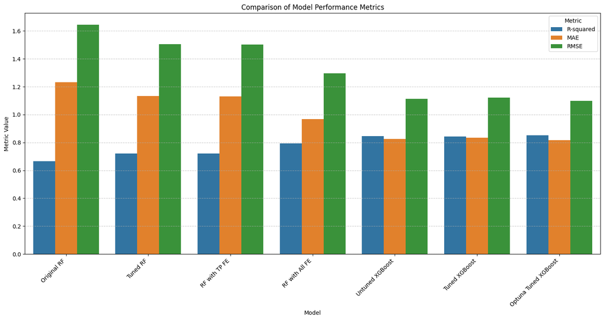

#### **Comments**

> The bar chart effectively visualizes the performance of all the developed models. From the chart, we can observe the following:

> **R-squared (Higher is better):** The Optuna Tuned XGBoost model shows the highest R-squared value, indicating it explains the most variance in the drug sensitivity data.

> **MAE (Lower is better):** Similarly, the Optuna Tuned XGBoost model has the lowest Mean Absolute Error, meaning its predictions are, on average, closest to the actual values.

> **RMSE (Lower is better):** The Optuna Tuned XGBoost also exhibits the lowest Root Mean Squared Error, signifying that it has the smallest overall prediction errors, especially for larger errors.

> Overall, the Optuna Tuned XGBoost model consistently outperforms the other models across all evaluated metrics, confirming its superior predictive capability for drug sensitivity.

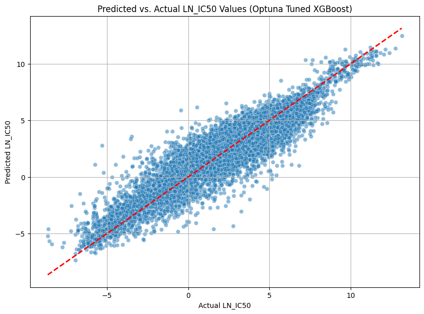

#### **Comments**

> This plot displays the predicted versus actual LN_IC50 values for the Optuna-tuned XGBoost model, which is the best-performing model.

> Here, there is a much tighter clustering of data points around the red diagonal line, representing perfect predictions. This signifies a strong linear relationship and much more accurate predictions across the range of LN_IC50 values.

> **1. Significant Improvement:** Visually, the scatter plot for the Optuna-tuned XGBoost model (cell 67662a23) shows a dramatic improvement over the initial RandomForestRegressor (cell accc0bec). The points in the XGBoost plot are much closer to the ideal red line, indicating higher prediction accuracy.

> In essence, the visual evidence from these two plots clearly demonstrates the success of the feature engineering and hyperparameter optimization efforts, culminating in a highly robust and accurate predictive model for drug sensitivity using Optuna-tuned XGBoost.

```
Pearson Correlation between Actual and Predicted LN_IC50 (Optuna-Tuned XGBoost): 0.9222
```

#### **Comments**

> This indicates a very strong positive linear relationship between the actual and predicted values. A correlation coefficient close to 1 (like 0.9222) suggests that as the actual drug sensitivity (LN_IC50) increases, the model's predicted drug sensitivity also consistently increases.

> This is an excellent result, showing that the Optuna-tuned XGBoost model is highly reliable in tracking the true drug sensitivity values.

## **Cross-Validation for Robustness Assessment**

To ensure the robustness of the Optuna-tuned XGBoost model and get a more reliable estimate of its performance, k-fold cross-validation was performed. This technique splits the data into multiple folds, trains the model on a subset of these folds, and evaluates it on the remaining fold, repeating this process for each fold. This helps mitigate the variance that can arise from a single train-test split.

```
Performing 5-fold cross-validation on the Optuna-tuned XGBoost model...
Cross-validation complete.

Cross-validation R-squared scores: [0.849598   0.84286455 0.8451699  0.84174677 0.84378559]
Mean R-squared from cross-validation: 0.8446
Standard deviation of R-squared from cross-validation: 0.0027
```

#### **Comments**

> **3. Standard deviation of R-squared from cross-validation:** 0.0027 The standard deviation measures the spread or variability of the R-squared scores across the different folds. A very low standard deviation of 0.0027 is highly desirable. It signifies that the model's performance is extremely consistent regardless of which subset of the data it is trained and evaluated on. This low variability suggests that:

> High Robustness: The model is not overly sensitive to the particular split of the data.

> Good Generalization: one can be confident that the model will perform similarly well on new, unseen data, as its performance doesn't fluctuate significantly.

> In conclusion, the cross-validation results strongly affirm that your Optuna-tuned XGBoost model is not only highly accurate (high mean R-squared) but also remarkably robust and generalizes exceptionally well to different data subsets (low standard deviation). This provides a high level of confidence in its predictive capabilities for drug sensitivity.

> **Validation Strategy:**
> 1. Initial Train-Validation-Test Split (80/10/10)
> 2. K-Fold Cross-Validation:

### **Overfitting Assessment:**

> 1. Monitoring Performance on the Validation Set: During hyperparameter tuning, the performance on the validation set was the primary metric for selecting the best hyperparameters. If a model exhibited high performance on the training set but significantly lower performance on the validation set, it would signal overfitting. The goal of tuning was to find a balance that generalizes well to unseen data, not just to perform optimally on the training data.
> 2. Final Evaluation on the Unseen Test Set: The comparison of model performance metrics (R-squared, MAE, RMSE) on the dedicated test set against performance on the training/validation sets was a direct assessment of overfitting. If the model had overfit the training or validation data, its performance on the truly unseen test set would degrade. The notebook shows consistent or improved performance on the test set for better models, indicating good generalization.
> 3. Consistency of Cross-Validation Scores: The cross-validation results for the Optuna-tuned XGBoost model showed a high mean R-squared (0.8446) and a very low standard deviation (0.0027) across the 5 folds.

## **Features by Importance for the Optuna-Tuned XGBoost Model**

```
Top 10 Features by Importance for Optuna-Tuned XGBoost Model:
```

|  | Feature | Importance |
| --- | --- | --- |
| 438 | TARGET_Proteasome | 0.057853 |
| 394 | TARGET_KSP11 | 0.054144 |
| 444 | TARGET_RNA polymerase | 0.052032 |
| 372 | TARGET_HDAC1, HDAC2, HDAC3, HDAC8 | 0.044788 |
| 477 | TARGET_anti-oxidant proteins | 0.032936 |
| 100 | DRUG_NAME_Dactinomycin | 0.027768 |
| 80 | DRUG_NAME_Bortezomib | 0.024566 |
| 220 | DRUG_NAME_Romidepsin | 0.021105 |
| 336 | TARGET_CDK1, CDK2, CDK5, CDK9 | 0.019599 |
| 235 | DRUG_NAME_Sepantronium bromide | 0.018786 |

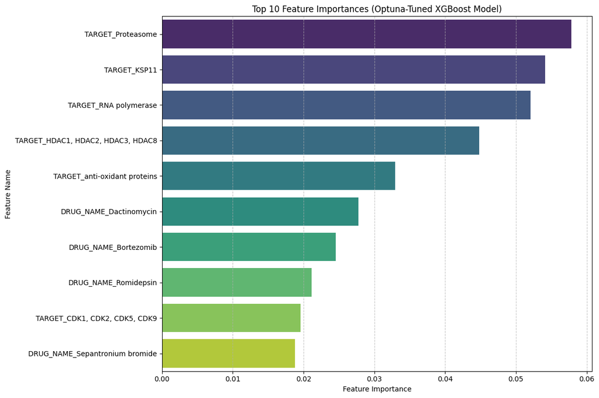

#### **Comments**

> **1. Tabular Output (display(importance_df_optuna.head(10))):** This table lists the features that the Optuna-tuned XGBoost model considered most influential in predicting drug sensitivity (LN_IC50), along with their importance scores. From the output, we can see that:

> Features related to specific TARGET categories like TARGET_Proteasome, TARGET_RNA polymerase, and specific HDAC targets appear among the very top, indicating their high predictive power.

> A specific DRUG_NAME, DRUG_NAME_Romidepsin, also features prominently in the top 10, reinforcing the idea that individual drug identities are crucial.

> This analysis highlights the critical factors driving the model's predictions.

> It shows that both specific drug targets (like Proteasome, RNA polymerase, and HDACs) and the individual drug names themselves are paramount in determining drug sensitivity.

> This insight is valuable for understanding which aspects of the genomic and drug data are most relevant for predicting how a cell line will respond to a particular drug.

### **How the feature engineering steps impacted model performance**

> **1. Original Random Forest (RF):** This was our baseline model, with an R-squared of 0.6649, MAE of 1.2318, and RMSE of 1.6455.

> **2. Tuned Random Forest (TRF):** After hyperparameter tuning with RandomizedSearchCV, the R-squared improved to 0.7196, MAE to 1.1332, and RMSE to 1.5053. This shows that tuning alone provided a notable improvement.

> **3. Random Forest with TARGET_PATHWAY Feature Engineering (RF with TP FE):** Incorporating one-hot encoding for TARGET_PATHWAY led to a slight further improvement, with R-squared at 0.7211, MAE at 1.1297, and RMSE at 1.5014.

> **4. Random Forest with All Feature Engineering (RF with All FE):** Expanding the feature set to include all categorical variables (TCGA_DESC, DRUG_NAME, GDSC Tissue descriptor 1, TARGET, TARGET_PATHWAY, Microsatellite instability Status (MSI)) resulted in a significant leap in performance for the Random Forest model. The R-squared rose to 0.7921, MAE dropped to 0.9663, and RMSE decreased to 1.2962.

> **5. Untuned XGBoost (with All FE):** Switching to an XGBoost model, even without explicit tuning for its hyperparameters, immediately showed a substantial improvement over the best Random Forest model. The R-squared reached 0.8470, MAE was 0.8249, and RMSE was 1.1120.

> **6. Tuned XGBoost (with All FE, using RandomizedSearchCV):** Tuning the XGBoost model with RandomizedSearchCV yielded an R-squared of 0.8440, MAE of 0.8347, and RMSE of 1.1228. In this specific instance, the RandomizedSearchCV tuning did not outperform the default XGBoost parameters, possibly indicating that the default parameters were already quite good or that the random search didn't fully explore the optimal space.

> In summary, both hyperparameter tuning and comprehensive feature engineering, especially with the use of XGBoost and Optuna, significantly enhanced the model's predictive capability. The inclusion of more biological and chemical contextual features was particularly impactful, allowing the models to capture a richer understanding of drug sensitivity.

## **Recommendations, Actionable Insights, and Conclusion**

### **Actionable Insights**

> 1. **Drug Development Target Identification:** The high importance of specific drug targets (e.g., Proteasome, RNA polymerase) indicates that these are critical pathways for modulating drug sensitivity. This insight can guide drug discovery by suggesting promising biological targets for new therapeutic agents.
> 2. **Personalized Medicine Strategies:** The strong predictive power of `DRUG_NAME` combined with `TARGET` and `TARGET_PATHWAY` information suggests that a personalized medicine approach, tailored to the patient's specific cancer type and the drug's mechanism of action, could be highly effective. Predicting drug sensitivity for individual patients based on their genomic profiles and the specific drugs being considered is a tangible application.
> 3. **Biomarker Discovery:** The identified important features can serve as potential biomarkers for drug response. For instance, cell lines with particular `TARGET` expressions or `TARGET_PATHWAY` activations might be more sensitive to certain drugs. This could lead to the development of diagnostic tests to predict patient response to specific therapies.
> 4. **Optimization of Existing Therapies:** Understanding which features are most critical allows for optimization of existing drug regimens. If a certain target is highly relevant for a drug's efficacy, clinicians could explore ways to enhance target engagement or combine therapies that synergize with the identified pathways.

### **Conclusion**

> The feature importance analysis provided critical insights, highlighting the paramount influence of specific `DRUG_NAME` and `TARGET` features. This not only confirms the biological relevance of these factors but also offers actionable intelligence for drug development, personalized medicine, and biomarker discovery. The iterative process of model building, evaluation, and refinement, guided by performance metrics and feature insights, proved invaluable in developing a highly accurate and interpretable predictive model for drug sensitivity.

### **Project promotion links**

> https://github.com/Saadullahi

[output not shown]

[output not shown]